# FML

srikanth chetlapally

2024-04-07

```r
getwd()
```

```
## [1] "C:/Users/srika/OneDrive/Desktop"
```

```r
setwd("C:/Users/srika/Downloads")
```

```r
# installing required packages
library(ISLR)
library(caret)
library(dplyr)
library(cluster)
library(factoextra)
library(NbClust)
library(ppclust)
library(dendextend)
library(tidyverse)
```

```r
library(ggplot2)
library(proxy)
```

First, read the data and remove rows with missing values.

```r
library(readr)
# To import the "cereal" data collection.
Cereals <- Cereals <- read_csv("C:/Users/srika/Downloads/Cereals.csv")
# Using head, obtain the first few rows of the data collection
head(Cereals)
```

```
## # A tibble: 6 × 16
##   name       mfr   type  calories protein   fat sodium fiber carbo sugars potass
##   <chr>      <chr> <chr>    <dbl>   <dbl> <dbl>  <dbl> <dbl> <dbl>  <dbl>  <dbl>
## 1 100%_Bran  N     C           70       4     1    130  10     5        6    280
## 2 100%_Natu… Q     C          120       3     5     15   2     8        8    135
## 3 All-Bran   K     C           70       4     1    260   9     7        5    320
## 4 All-Bran_… K     C           50       4     0    140  14     8        0    330
## 5 Almond_De… R     C          110       2     2    200   1    14        8     NA
## 6 Apple_Cin… G     C          110       2     2    180   1.5  10.5     10     70
## # ℹ 5 more variables: vitamins <dbl>, shelf <dbl>, weight <dbl>, cups <dbl>,
## #   rating <dbl>
```

```r
# Using str to analyze the data set's structure
str(Cereals)
```

```
## spc_tbl_ [77 × 16] (S3: spec_tbl_df/tbl_df/tbl/data.frame)
##  $ name    : chr [1:77] "100%_Bran" "100%_Natural_Bran" "All-Bran" "All-Bran_with_Extra_Fiber" ...
##  $ mfr     : chr [1:77] "N" "Q" "K" "K" ...
##  $ type    : chr [1:77] "C" "C" "C" "C" ...
##  $ calories: num [1:77] 70 120 70 50 110 110 110 130 90 90 ...
##  $ protein : num [1:77] 4 3 4 4 2 2 2 3 2 3 ...
##  $ fat     : num [1:77] 1 5 1 0 2 2 0 2 1 0 ...
##  $ sodium  : num [1:77] 130 15 260 140 200 180 125 210 200 210 ...
##  $ fiber   : num [1:77] 10 2 9 14 1 1.5 1 2 4 5 ...
##  $ carbo   : num [1:77] 5 8 7 8 14 10.5 11 18 15 13 ...
##  $ sugars  : num [1:77] 6 8 5 0 8 10 14 8 6 5 ...
##  $ potass  : num [1:77] 280 135 320 330 NA 70 30 100 125 190 ...
##  $ vitamins: num [1:77] 25 0 25 25 25 25 25 25 25 25 ...
##  $ shelf   : num [1:77] 3 3 3 3 3 1 2 3 1 3 ...
##  $ weight  : num [1:77] 1 1 1 1 1 1 1 1.33 1 1 ...
##  $ cups    : num [1:77] 0.33 1 0.33 0.5 0.75 0.75 1 0.75 0.67 0.67 ...
##  $ rating  : num [1:77] 68.4 34 59.4 93.7 34.4 ...
##  - attr(*, "spec")=
##   .. cols(
##   ..   name = col_character(),
##   ..   mfr = col_character(),
##   ..   type = col_character(),
##   ..   calories = col_double(),
##   ..   protein = col_double(),
##   ..   fat = col_double(),
##   ..   sodium = col_double(),
##   ..   fiber = col_double(),
##   ..   carbo = col_double(),
##   ..   sugars = col_double(),
##   ..   potass = col_double(),
##   ..   vitamins = col_double(),
##   ..   shelf = col_double(),
##   ..   weight = col_double(),
##   ..   cups = col_double(),
##   ..   rating = col_double()
##   .. )
##  - attr(*, "problems")=<externalptr>
```

```r
#applying the summary to analyze the data set
summary(Cereals)
```

```
##      name               mfr                type              calories
##  Length:77          Length:77          Length:77          Min.   : 50.0
##  Class :character   Class :character   Class :character   1st Qu.:100.0
##  Mode  :character   Mode  :character   Mode  :character   Median :110.0
##                                                           Mean   :106.9
##                                                           3rd Qu.:110.0
##                                                           Max.   :160.0
##
##     protein           fat            sodium          fiber
##  Min.   :1.000   Min.   :0.000   Min.   :  0.0   Min.   : 0.000
##  1st Qu.:2.000   1st Qu.:0.000   1st Qu.:130.0   1st Qu.: 1.000
##  Median :3.000   Median :1.000   Median :180.0   Median : 2.000
##  Mean   :2.545   Mean   :1.013   Mean   :159.7   Mean   : 2.152
##  3rd Qu.:3.000   3rd Qu.:2.000   3rd Qu.:210.0   3rd Qu.: 3.000
##  Max.   :6.000   Max.   :5.000   Max.   :320.0   Max.   :14.000
##
##      carbo          sugars           potass          vitamins
##  Min.   : 5.0   Min.   : 0.000   Min.   : 15.00   Min.   :  0.00
##  1st Qu.:12.0   1st Qu.: 3.000   1st Qu.: 42.50   1st Qu.: 25.00
##  Median :14.5   Median : 7.000   Median : 90.00   Median : 25.00
##  Mean   :14.8   Mean   : 7.026   Mean   : 98.67   Mean   : 28.25
##  3rd Qu.:17.0   3rd Qu.:11.000   3rd Qu.:120.00   3rd Qu.: 25.00
##  Max.   :23.0   Max.   :15.000   Max.   :330.00   Max.   :100.00
##  NA's   :1      NA's   :1        NA's   :2
##      shelf           weight          cups           rating
##  Min.   :1.000   Min.   :0.50   Min.   :0.250   Min.   :18.04
##  1st Qu.:1.000   1st Qu.:1.00   1st Qu.:0.670   1st Qu.:33.17
##  Median :2.000   Median :1.00   Median :0.750   Median :40.40
##  Mean   :2.208   Mean   :1.03   Mean   :0.821   Mean   :42.67
##  3rd Qu.:3.000   3rd Qu.:1.00   3rd Qu.:1.000   3rd Qu.:50.83
##  Max.   :3.000   Max.   :1.50   Max.   :1.500   Max.   :93.70
##
```

Now I am scaling the data to remove NA values from the data set.

```r
# For preparation, I'm creating a clone of this data set here.
Scaled_Cereals <- Cereals
# I'm scaling the data set right now to fit it into a clustering approach.
Scaled_Cereals[ , c(4:16)] <- scale(Cereals[ , c(4:16)])
#Here, I'm eliminating the NA values from the data collection using the omit function.
Preprocessed_Cereal <- na.omit(Scaled_Cereals)
# Utilizing head to show the top five rows after removing NA
head(Preprocessed_Cereal)
```

```
## # A tibble: 6 × 16
##   name  mfr   type  calories protein     fat sodium   fiber  carbo sugars potass
##   <chr> <chr> <chr>    <dbl>   <dbl>   <dbl>  <dbl>   <dbl>  <dbl>  <dbl>  <dbl>
## 1 100%… N     C       -1.89    1.33  -0.0129 -0.354  3.29   -2.51  -0.234  2.58
## 2 100%… Q     C        0.673   0.415  3.96   -1.73  -0.0638 -1.74   0.222  0.516
## 3 All-… K     C       -1.89    1.33  -0.0129  1.20   2.87   -2.00  -0.463  3.14
## 4 All-… K     C       -2.92    1.33  -1.01   -0.235  4.97   -1.74  -1.60   3.29
## 5 Appl… G     C        0.160  -0.498  0.981   0.242 -0.274  -1.10   0.679 -0.407
## 6 Appl… K     C        0.160  -0.498 -1.01   -0.414 -0.483  -0.973  1.59  -0.975
## # ℹ 5 more variables: vitamins <dbl>, shelf <dbl>, weight <dbl>, cups <dbl>,
## #   rating <dbl>
```

Following pre-processing and scaling, there were 74 observations overall as opposed to 77 before. There were just 3 records with the value “NA.”

Question Apply hierarchical clustering to the data using Euclidean distance to the normalized measurements. Use Agnes to compare the clustering from single linkage, complete linkage, average linkage, and Ward. Choose the best method.

Solution

Single Linkage:

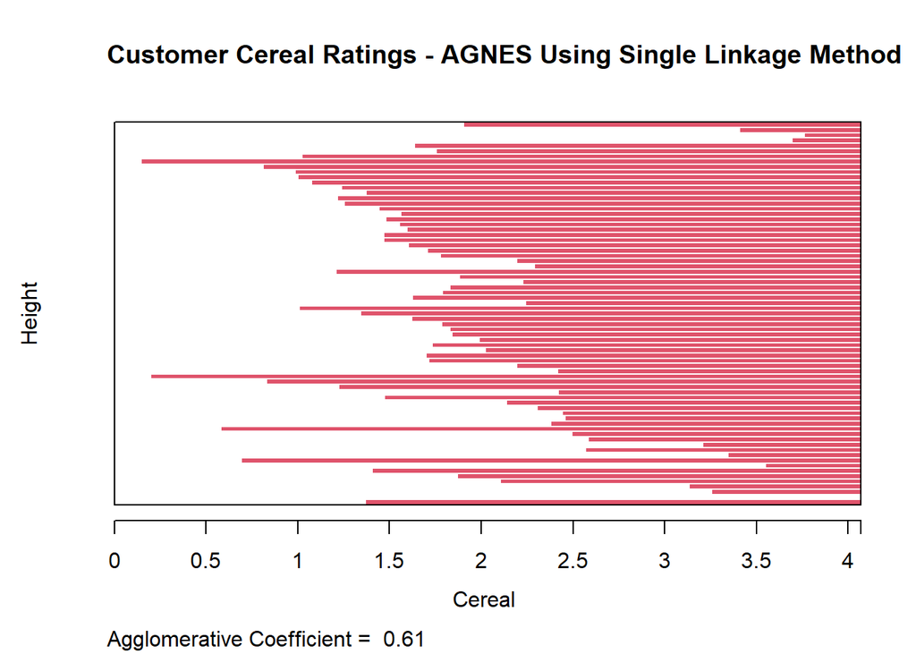

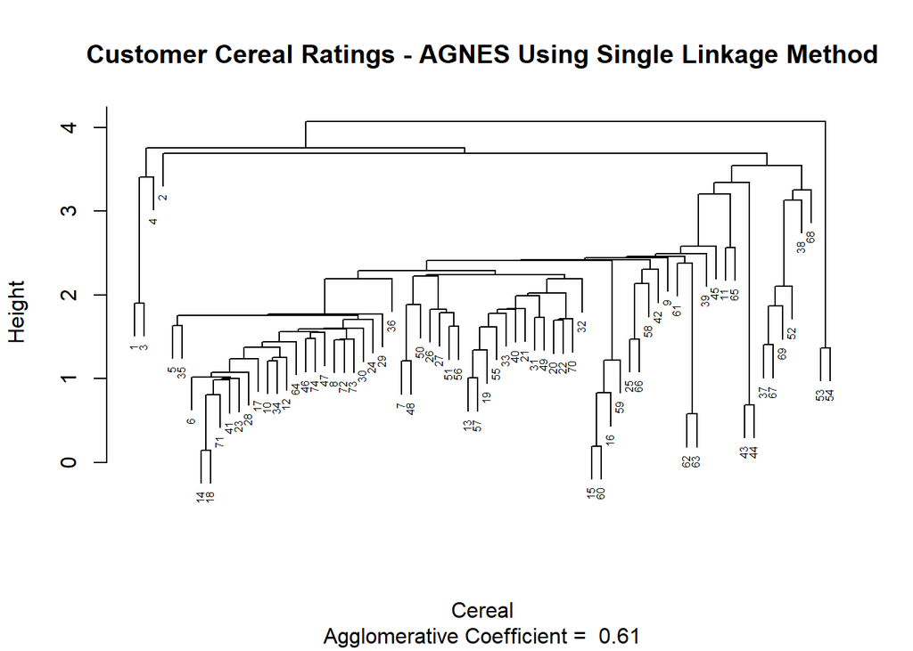

```r
#For all of the numerical values, the dissimilarity matrix is created
#using Euclidean distance measurements.
Cereal_Euclidean <- dist(Preprocessed_Cereal[ , c(4:16)], method = "euclidean")
# A hierarchical clustering is carried out using the single linkage approach.
HC_Single <- agnes(Cereal_Euclidean, method = "single")
# Here, I'm charting the results of the several methods.
plot(HC_Single,
main = "Customer Cereal Ratings - AGNES Using Single Linkage Method",
xlab = "Cereal",
ylab = "Height",
cex.axis = 1,
cex = 0.50)
```

Complete Linkage:

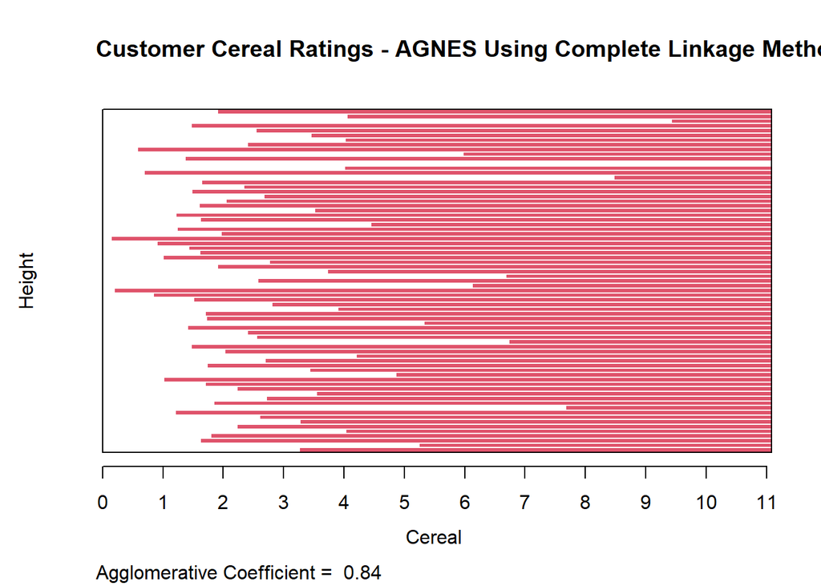

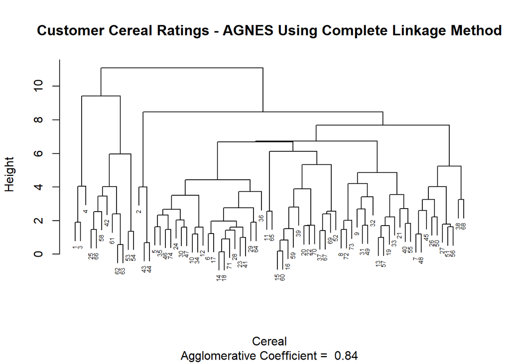

```r
# utilizing the complete linkage technique to carry out hierarchical clustering
HC_Complete <- agnes(Cereal_Euclidean, method = "complete")
#Here, I'm charting the results of the several methods.
plot(HC_Complete,
main = "Customer Cereal Ratings - AGNES Using Complete Linkage Method",
xlab = "Cereal",
ylab = "Height",
cex.axis = 1,
cex = 0.50)
```

Average Linkage:

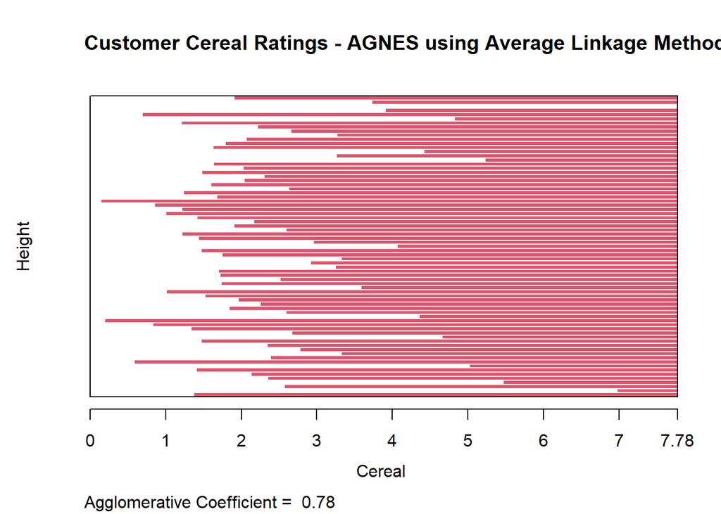

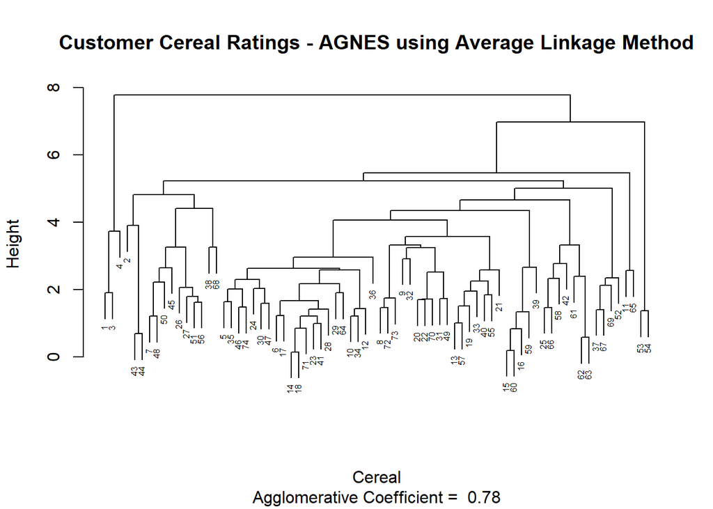

```r
# Utilizing the hierarchical clustering technique of average linkage
HC_Average <- agnes(Cereal_Euclidean, method = "average")
# I'm plotting the outcomes of the various approaches here.
plot(HC_Average,
main = "Customer Cereal Ratings - AGNES using Average Linkage Method",
xlab = "Cereal",
ylab = "Height",
cex.axis = 1,
cex = 0.50)
```

Ward Method:

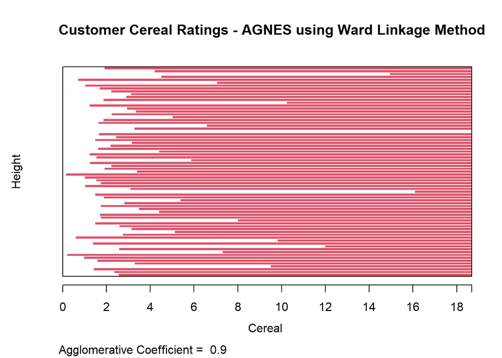

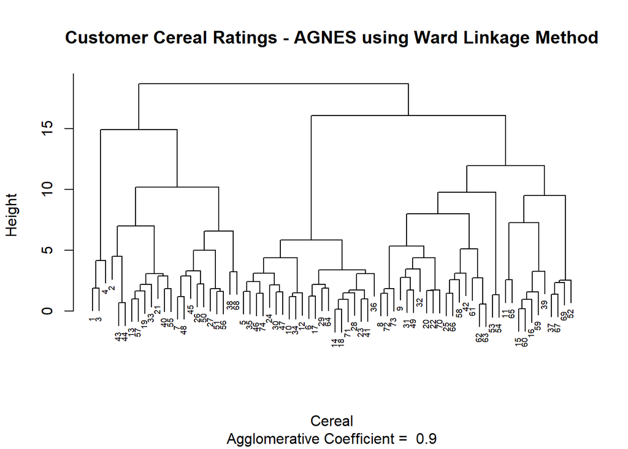

```r
# Using the ward linkage technique to create hierarchical clusters
HC_Ward <- agnes(Cereal_Euclidean, method = "ward")
# I'm charting the results of the various approaches.
plot(HC_Ward,
main = "Customer Cereal Ratings - AGNES using Ward Linkage Method",
xlab = "Cereal",
ylab = "Height",
cex.axis = 1,
cex = 0.55)
```

The closer the clustering structure, the closer the value is to 1.0. Consequently, the strategy that has the value closest to 1.0 will be chosen. Linkage Only: 0.61 Total Connection: 0.84 Linkage on average: 0.78 Ward Approach: 0.90 Here The Ward approach is the most effective clustering model based on the results.

Question:How many clusters would you choose?